# PrinStat - Lab 1: Initial Data Analysis

This [R Markdown Notebook](https://bookdown.org/yihui/rmarkdown/notebook.html) can best be viewed by clicking the button *Visual* above (instead of *Source*). The R code in each code chunk below can be executed by clicking the *Run* button (or with the short-cut *Ctrl-Shift-Enter*). Single lines of code can be executed by selecting the option *Run Selected Line(s)* from the drop-down menu in *Run* (or with the short-cut *Ctrl-Enter*). The results of each computation will appear below the code chunks.

As is customary, we first load the necessary packages for this Notebook:

```r
library(car)
library(googledrive)
library(tidyverse)
```

```r
library(car)
library(googledrive)
library(tidyverse)
```

A CSV file called *PrinStat Student Survey.csv* (or perhaps *PrinStat Student Survey - Responses.csv*) has now been saved in your working directory, which is probably the folder where you put this R Notebook.

## Read data

You can read the data into R with the following command and select the file. It may be the case that you need to change the argument `sep = ","` (manually) into `sep = ";"` (and if you get a warning about an incomplete final line, then you can ignore it, since this is an old bug in R):

```r
dat <- read.csv(file.choose(), header = TRUE, sep = ",")    # or: sep = ";"
```

If you’re not sure what `read.csv()` does, then consult the help pages by typing:

```r
dat <- read.csv(file.choose(), header = TRUE, sep = ",")    # or: sep = ";"
```

or:

```r
?read.csv
```

Since about 2015 many people use the [tidyverse](https://www.tidyverse.org/) suite/family of packages to handle data. The tidyverse’s functions for reading data (part of the subpackage **readr**) closely resemble base R’s functions but they have an underscore (`_`) in their name instead of a dot (`.`):

```r
?read.table
```

The file formats which the **readr** package can handle are the same as base R’s functions. Excel files can be read in directly by means of the **readxl** or **xlsx** package. Data files of statistical software such as *SAS*, *Stata*, *SPSS* etc. can be read using the packages **foreign** and/or **haven**.

An alternative option to selecting a file with the `file.choose()` function is to use a relative (rather than an absolute) path: First change your working directory in R to the directory where the data file is stored, using `setwd()` or:

- in R (windows): *File - Change dir…* (make sure you have the console selected)
- in R (mac): *Misc - Change Working Directory…*
- in RStudio: *Session - Set Working Directory - Choose Directory…*

If your data is in the same directory as this Notebook then changing the working directory to that directory is even simpler in Rstudio: *Session - Set Working Directory - To Source File Location*.

If you have changed the working directory to the directory containing the data file, then you can just run the command with the file name, e.g.:

```
# Not run:
dat <- read.table("PrinStat Student Survey.csv", header = TRUE,
                  sep = ",")
```

Some functions for a first exploration:

```r
head(dat)
```

```r
head(dat)
```

|  | Timestamp | Gender | Nationality | Date.of.Birth | Academic.background | R.course | R.skills | Distance.to.class | Time.to.get.here | Means.of.transportation | Where.did.you.here.about.the.MaStat.program. | Music.preference |
| --- | --- | --- | --- | --- | --- | --- | --- | --- | --- | --- | --- | --- |
| 1 | 08/02/2025 16:28:41 |  |  |  |  |  |  | 10000 | NA |  |  |  |
| 2 | 08/02/2025 16:28:47 |  |  |  |  |  |  | NA | NA |  |  |  |
| 3 | 08/02/2025 16:28:53 |  |  |  |  |  |  | NA | NA |  |  |  |
| 4 | 25/09/2025 10:02:44 | female | China | 16/01/1993 | Mathematics | yes | Low | 92 | 99 | public transportation (bus and/or train) | UGent Website | House/Techno |
| 5 | 25/09/2025 10:06:30 | female | Belgium | 28/09/2001 | Psychology | no | Intermediate | 6 | 20 | bike | UGent Website | Classical |
| 6 | 25/09/2025 10:06:49 | male | Colombia | 10/12/1992 | Social Sciences | yes | Intermediate | 3 | 30 | public transportation (bus and/or train) | Other | Classical |

```r
tail(dat)
```

|  | Timestamp | Gender | Nationality | Date.of.Birth | Academic.background | R.course | R.skills | Distance.to.class | Time.to.get.here | Means.of.transportation | Where.did.you.here.about.the.MaStat.program. | Music.preference |
| --- | --- | --- | --- | --- | --- | --- | --- | --- | --- | --- | --- | --- |
| 23 | 25/09/2025 10:11:29 | female | India | 30/05/1988 | Electrical and Electronic Engineering | no | Low | 3.0 | 25 | public transportation (bus and/or train) | UGent Website | Rap/slow jam |
| 24 | 25/09/2025 10:11:55 | female | Belgium | 19/11/1990 | Biological Sciences | yes | Low | 2.5 | 15 | bike | UGent Website | Classical |
| 25 | 25/09/2025 10:12:14 | female | Belgium | 15/05/1999 | Management Science / Operations Research | no | Low | 2.0 | 7 | bike | Friend/Colleague | Classical |
| 26 | 25/09/2025 10:12:27 | female | Vietnam | 25/09/2025 | Economics | no | Low | 5.0 | 30 | bike | UGent Website | Classical |
| 27 | 25/09/2025 10:12:51 | female | Belgium | 04/04/1999 | Sports and Recreation | no | Low | 15.0 | 30 | bike | UGent Website | Classical |
| 28 | 25/09/2025 10:13:13 |  |  | 25/09/2025 | Arts and literature | yes | None | 0.0 | 0 | public transportation (bus and/or train) | Friend/Colleague | Classical |

```r
names(dat)
```

```
 [1] "Timestamp"
 [2] "Gender"
 [3] "Nationality"
 [4] "Date.of.Birth"
 [5] "Academic.background"
 [6] "R.course"
 [7] "R.skills"
 [8] "Distance.to.class"
 [9] "Time.to.get.here"
[10] "Means.of.transportation"
[11] "Where.did.you.here.about.the.MaStat.program."
[12] "Music.preference"
```

```r
dim(dat)
```

```
[1] 28 12
```

RMarkdown documents such as this R Notebook by default print data frames in an elegant way, easy to inspect by a user. Compare the ordinary way in which R output would appear in the console:

```r
str(dat)
```

```
'data.frame':   28 obs. of  12 variables:
 $ Timestamp                                   : chr  "08/02/2025 16:28:41" "08/02/2025 16:28:47" "08/02/2025 16:28:53" "25/09/2025 10:02:44" ...
 $ Gender                                      : chr  "" "" "" "female" ...
 $ Nationality                                 : chr  "" "" "" "China" ...
 $ Date.of.Birth                               : chr  "" "" "" "16/01/1993" ...
 $ Academic.background                         : chr  "" "" "" "Mathematics" ...
 $ R.course                                    : chr  "" "" "" "yes" ...
 $ R.skills                                    : chr  "" "" "" "Low" ...
 $ Distance.to.class                           : num  10000 NA NA 92 6 3 75 25 3 6 ...
 $ Time.to.get.here                            : int  NA NA NA 99 20 30 80 25 9 40 ...
 $ Means.of.transportation                     : chr  "" "" "" "public transportation (bus and/or train)" ...
 $ Where.did.you.here.about.the.MaStat.program.: chr  "" "" "" "UGent Website" ...
 $ Music.preference                            : chr  "" "" "" "House/Techno" ...
```

```r
head(dat)
```

```
            Timestamp Gender Nationality Date.of.Birth
1 08/02/2025 16:28:41
2 08/02/2025 16:28:47
3 08/02/2025 16:28:53
4 25/09/2025 10:02:44 female       China    16/01/1993
5 25/09/2025 10:06:30 female     Belgium    28/09/2001
6 25/09/2025 10:06:49   male    Colombia    10/12/1992
  Academic.background R.course     R.skills
1
2
3
4         Mathematics      yes          Low
5          Psychology       no Intermediate
6     Social Sciences      yes Intermediate
  Distance.to.class Time.to.get.here
1             10000               NA
2                NA               NA
3                NA               NA
4                92               99
5                 6               20
6                 3               30
                   Means.of.transportation
1
2
3
4 public transportation (bus and/or train)
5                                     bike
6 public transportation (bus and/or train)
  Where.did.you.here.about.the.MaStat.program.
1
2
3
4                                UGent Website
5                                UGent Website
6                                        Other
  Music.preference
1
2
3
4     House/Techno
5        Classical
6        Classical
```

Or, Variables/Columns in data sets can be accessed using the dollar sign operator (`$`):

```r
tail(dat)
```

```
             Timestamp Gender Nationality Date.of.Birth
23 25/09/2025 10:11:29 female       India    30/05/1988
24 25/09/2025 10:11:55 female     Belgium    19/11/1990
25 25/09/2025 10:12:14 female     Belgium    15/05/1999
26 25/09/2025 10:12:27 female     Vietnam    25/09/2025
27 25/09/2025 10:12:51 female     Belgium    04/04/1999
28 25/09/2025 10:13:13                       25/09/2025
                        Academic.background R.course
23    Electrical and Electronic Engineering       no
24                      Biological Sciences      yes
25 Management Science / Operations Research       no
26                                Economics       no
27                    Sports and Recreation       no
28                      Arts and literature      yes
   R.skills Distance.to.class Time.to.get.here
```

[output cut: 27 more lines]

```r
Gender    # Error
```

```
错误: 找不到对象'Gender'
```

**Avoid** using `attach()`: you’ll eventually get into trouble!

```
# Not run:
attach(dat)
Gender
detach(dat)
Gender    # Error
```

Instead, it is good practice to use function `with()` if you want to avoid the dollar sign operator. This function has the same meaning as tidyverse’s “pipe operator” (`%>%`) in a “pipe chain”:

```r
with(dat, Gender)
```

```r
with(dat, Gender)
```

```
 [1] ""       ""       ""       "female" "female"
 [6] "male"   "male"   "male"   "female" "female"
[11] "female" "male"   "male"   "male"   "male"
[16] "male"   "male"   "male"   "male"   "male"
[21] "male"   "male"   "female" "female" "female"
[26] "female" "female" ""
```

```r
dat %>% pull(Gender)
```

```
 [1] ""       ""       ""       "female" "female"
 [6] "male"   "male"   "male"   "female" "female"
[11] "female" "male"   "male"   "male"   "male"
[16] "male"   "male"   "male"   "male"   "male"
[21] "male"   "male"   "female" "female" "female"
[26] "female" "female" ""
```

## Univariate descriptives

### Categorical variables

```r
with(dat, str(Gender))
```

Let’s see how many men/women/… are in this lab:

```r
with(dat, str(Gender))
```

```
 chr [1:28] "" "" "" "female" "female" "male" "male" ...
```

```r
with(dat, table(Gender))
```

```
Gender
       female   male
     4     10     14
```

To explicitly let R know that level `""` is in fact a **missing value**, we need to recode `Gender` by assigning the new value `NA` to observations with `Gender == ""` (another option is to use `ifelse()` - see below).

```r
dat %>% count(Gender)
```

```
  Gender  n
1         4
2 female 10
3   male 14
```

```r
with(dat, is.na(Gender))
```

```
 [1] FALSE FALSE FALSE FALSE FALSE FALSE FALSE FALSE
 [9] FALSE FALSE FALSE FALSE FALSE FALSE FALSE FALSE
[17] FALSE FALSE FALSE FALSE FALSE FALSE FALSE FALSE
[25] FALSE FALSE FALSE FALSE
```

```r
?`[`
```

```r
with(dat, Gender[1])
```

```
[1] ""
```

However, R does not consider `Gender` to be a factor (with either two or three levels):

```r
with(dat, Gender[dat$Gender == "female"])
```

```
 [1] "female" "female" "female" "female" "female"
 [6] "female" "female" "female" "female" "female"
```

By recoding it as a factor, the empty level `""` becomes a third level. Such transforming of a variable can be done with tidyverse’s function `mutate()` (from the subpackage **dplyr**) or with R’s base function `within()` (but **not** with the deprecated function `transform()`):

```r
with(dat, levels(Gender))
```

The empty level can be excluded from the computations:

```r
dat <- within(dat, Gender <- factor(Gender))
with(dat, levels(Gender))
```

```
[1] ""       "female" "male"
```

```r
with(dat, table(Gender, exclude = NULL))    # show missing values
```

```
Gender
       female   male
     4     10     14
```

By replacing empty levels with `NA`, they are only dropped by coding the transformed variable again as a factor. However, don’t forget to include them in your computations if you want to report missing values:

```r
with(dat, table(Gender, exclude = ""))    # without missing values
```

```
Gender
female   male
    10     14
```

```r
dat <- within(dat, Gender <- factor(na_if(Gender, "")))
with(dat, is.na(Gender))
```

```
 [1]  TRUE  TRUE  TRUE FALSE FALSE FALSE FALSE FALSE
 [9] FALSE FALSE FALSE FALSE FALSE FALSE FALSE FALSE
[17] FALSE FALSE FALSE FALSE FALSE FALSE FALSE FALSE
[25] FALSE FALSE FALSE  TRUE
```

Now, everything in percentages, using the function `prop.table()`:

```r
with(dat, table(Gender, exclude = NULL))
```

```
Gender
female   male   <NA>
    10     14      4
```

```r
with(dat, prop.table(table(Gender, exclude = NULL)))
```

```
Gender
   female      male      <NA>
0.3571429 0.5000000 0.1428571
```

```r
tab <- with(dat, table(Gender, exclude = NULL))
tab
```

```
Gender
female   male   <NA>
    10     14      4
```

The proper graph for a categorical variable is a **bar chart**:

```r
prop.table(tab)
```

```
Gender
   female      male      <NA>
0.3571429 0.5000000 0.1428571
```

However, you see that `plot()` automatically excludes missing values. To also display these you can use the function `barplot()` with the appropriate levels specified to the argument `names.arg`:

```r
barplot(tab, ylab = "Absolute Frequency",
        names.arg = c("female", "male", "NA"), xlab = "Gender")
```

The order of the levels specified to `names.arg` is important. Indeed, know what you are doing:

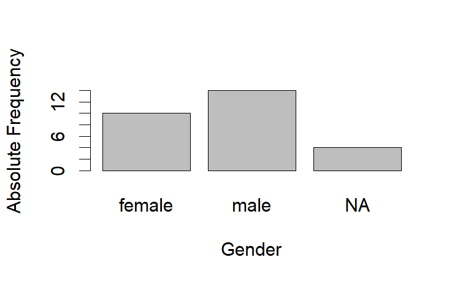

```r
barplot(tab, ylab = "Absolute Frequency",
        names.arg = c("female", "male", "NA"), xlab = "Gender")
```

[figure not shown]

```r
barplot(prop.table(tab), ylab = "Percentage")    # Uninformative
```

[output not shown]

[figure not shown]

```r
barplot(prop.table(tab), ylab = "Percentage",
        names.arg = c("X", "female", "male", "NA"), xlab = "Gender")    # Error
```

Of course, bar charts can also be made with tidyverse’s subpackage **ggplot2**. A difficulty is that its plots cannot be included in a pipe chain (with `%>%`). Instead, they use their own `+` operator to add various “layers” to a plot:

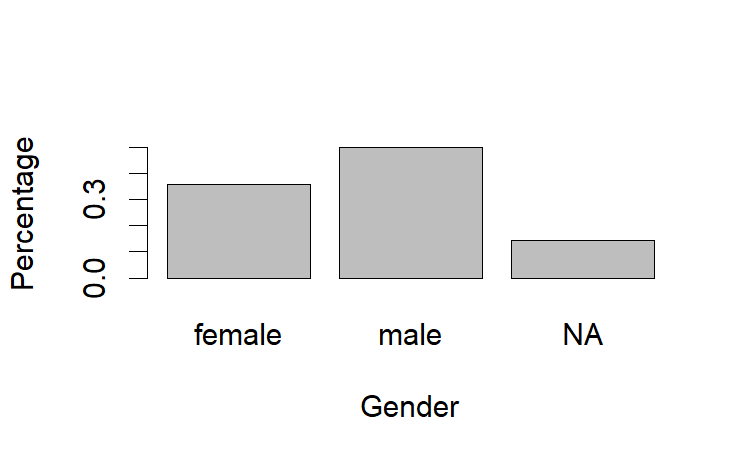

```r
barplot(tab / length(dat$Gender), ylab = "Percentage",
        names.arg = c("female", "male", "NA"), xlab = "Gender")
```

A(nother) quirk of **ggplot2** is that there is no straightforward way to create bar charts with relative frequencies:

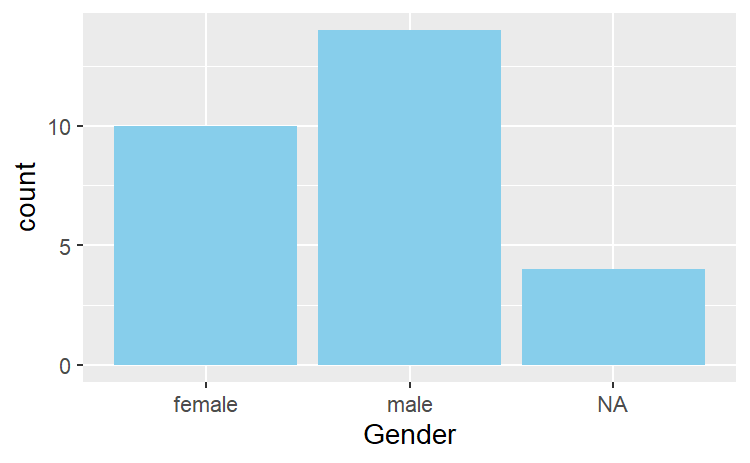

```r
plt_Gender <- ggplot(data = dat, mapping = aes(x = Gender)) +
  geom_bar(fill = "skyblue")
plt_Gender
```

Note the typical terminology in **ggplot2** (which refers to [Grammar of Graphics](https://link.springer.com/book/10.1007/0-387-28695-0)):

- An *aesthetic* specifies how a certain variable/column of a data frame is represented in the graph. Such a representation is called a mapping and it is specified with the argument `mapping` using the function `aes()`. For instance, the variable `Gender` is represented on the horizontal axis by mapping it to the `x` aesthetic.
- A *geom* or *geom layer* specifies the (geometrical) shape in which the individual data values are represented. For instance, the frequencies of the levels of a categorical variable (such as `Gender`) can be represented in a bar geom, specified by the layer function `geom_bar()`.

Next to geom layers, there are (among others) also *stat layers* which apply statistical transformations to the data values before visualizing them. For instance, the level frequencies in a categorical variable first need to be counted in order to visualize them in bars. That is why a bar geom by default also uses a stat layer `stat_count()`. Every geom layer has a default stat layer and vice versa, which you can override yourself. See the details in the help pages of the **gglot2** package.

We investigate some other categorical variables (or “factors”):

```r
with(dat, Nationality)
```

```r
with(dat, Nationality)
```

```
 [1] ""         ""         ""         "China"
 [5] "Belgium"  "Colombia" "Belgium"  "Israel"
 [9] "Belgium"  "China"    "Turkey"   "Belgium"
[13] "Belgium"  "Belgium"  "Ukraine"  "Belgium"
[17] "Belgium"  "France"   "Belgium"  "Ukraine"
[21] "India"    "Turkey"   "India"    "Belgium"
[25] "Belgium"  "Vietnam"  "Belgium"  ""
```

Recode `Nationality` into binary variable called `Belgian` indicating Belgian vs. Other nationality:

```r
dat <- within(dat, Nationality <- na_if(Nationality, ""))
with(dat, Nationality)
```

```
 [1] NA         NA         NA         "China"
 [5] "Belgium"  "Colombia" "Belgium"  "Israel"
 [9] "Belgium"  "China"    "Turkey"   "Belgium"
[13] "Belgium"  "Belgium"  "Ukraine"  "Belgium"
[17] "Belgium"  "France"   "Belgium"  "Ukraine"
[21] "India"    "Turkey"   "India"    "Belgium"
[25] "Belgium"  "Vietnam"  "Belgium"  NA
```

```r
dat <- within(dat,
              Belgian <- ifelse(Nationality == "Belgium", "BEL", "Other")
              )
with(dat, Belgian)
```

[output not shown]

Also recode it to a factor:

```r
with(dat, str(Belgian))
```

```
 chr [1:28] NA NA NA "Other" "BEL" "Other" "BEL" ...
```

```r
dat <- within(dat, Belgian <- factor(Belgian))
with(dat, Belgian)
```

```
 [1] <NA>  <NA>  <NA>  Other BEL   Other BEL   Other
 [9] BEL   Other Other BEL   BEL   BEL   Other BEL
[17] BEL   Other BEL   Other Other Other Other BEL
[25] BEL   Other BEL   <NA>
Levels: BEL Other
```

```r
tab <- with(dat, table(Belgian, exclude = NULL))
prop.table(tab)
```

```
Belgian
      BEL     Other      <NA>
0.4285714 0.4285714 0.1428571
```

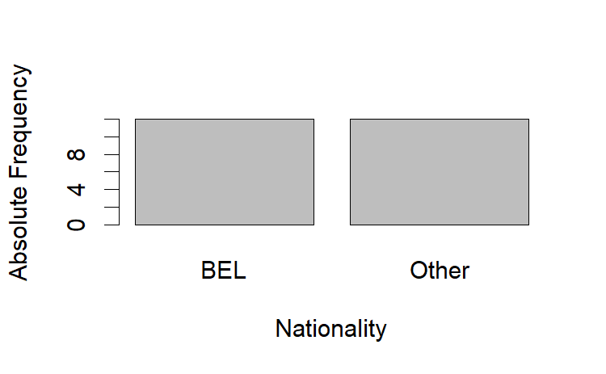

```r
with(dat, plot(Belgian, xlab = "Nationality", ylab = "Absolute Frequency"))
```

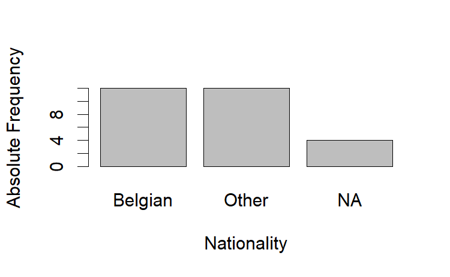

```r
barplot(tab, xlab = "Nationality", ylab = "Absolute Frequency",
        names.arg = c("Belgian", "Other", "NA"))
```

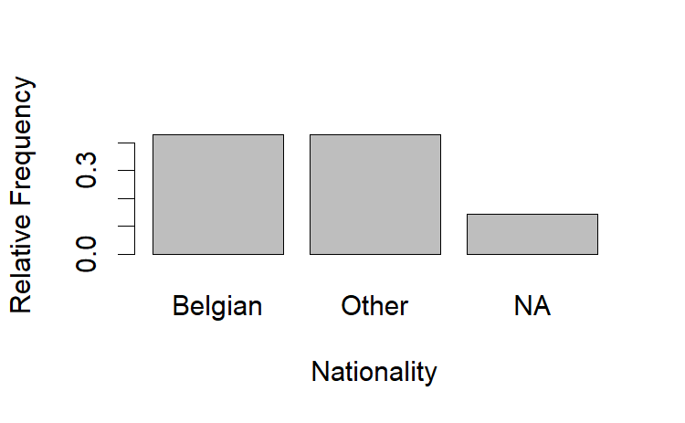

```r
barplot(prop.table(tab), xlab = "Nationality", ylab = "Relative Frequency",
        names.arg = c("Belgian", "Other", "NA"))
```

Although R has the function `pie()`, it is recommended to **not** use pie charts if the number of levels is large, and perhaps you should avoid pie charts altogether from three levels onwards. See http://en.wikipedia.org/wiki/Pie_chart, especially the section *Use and effectiveness*.

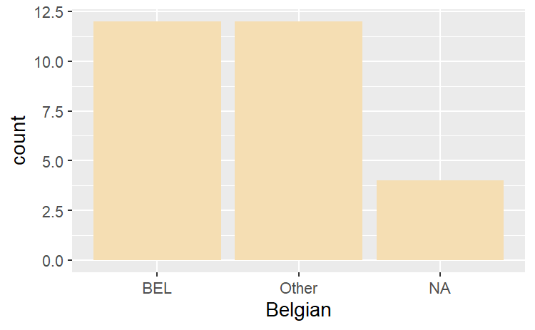

[figure not shown]

```r
ggplot(data = dat, mapping = aes(x = Belgian)) + geom_bar(fill = "wheat")
```

```r
with(dat, `Academic background`)
```

```
 [1] ""
 [2] ""
 [3] ""
 [4] "Mathematics"
 [5] "Psychology"
 [6] "Social Sciences"
 [7] "Biological Sciences"
 [8] "Psychology"
 [9] "Statistics / Data Science"
[10] "Medicine"
[11] "Engineering"
[12] "Earth Sciences"
[13] "Life Sciences"
[14] "Linguistics"
[15] "Social Sciences"
[16] "Linguistics"
[17] "Sports and Recreation"
[18] "Psychology"
[19] "Statistics / Data Science"
[20] "Social Sciences"
[21] "Mathematics"
[22] "Biological Sciences"
[23] "Electrical and Electronic Engineering"
[24] "Biological Sciences"
[25] "Management Science / Operations Research"
[26] "Economics"
[27] "Sports and Recreation"
[28] "Arts and literature"
```

```r
dat <- within(dat,
              Academic_background <- factor(na_if(`Academic background`, "")))
with(dat, table(Academic_background, exclude = NULL))
```

```
Academic_background
                     Arts and literature
                                       1
                     Biological Sciences
                                       3
                          Earth Sciences
                                       1
                               Economics
                                       1
   Electrical and Electronic Engineering
                                       1
                             Engineering
                                       1
                           Life Sciences
                                       1
                             Linguistics
                                       2
Management Science / Operations Research
                                       1
                             Mathematics
                                       2
                                Medicine
                                       1
                              Psychology
                                       3
                         Social Sciences
                                       3
                   Sports and Recreation
                                       2
               Statistics / Data Science
                                       2
                                    <NA>
                                       3
```

```r
tab <- with(dat, table(Academic_background, exclude = NULL))
tab
```

```
Academic_background
                     Arts and literature
                                       1
                     Biological Sciences
                                       3
                          Earth Sciences
                                       1
                               Economics
                                       1
   Electrical and Electronic Engineering
                                       1
                             Engineering
                                       1
                           Life Sciences
                                       1
                             Linguistics
                                       2
Management Science / Operations Research
                                       1
                             Mathematics
                                       2
                                Medicine
                                       1
                              Psychology
                                       3
                         Social Sciences
                                       3
                   Sports and Recreation
                                       2
               Statistics / Data Science
                                       2
                                    <NA>
                                       3
```

```r
prop.table(tab)
```

```
Academic_background
                     Arts and literature
                              0.03571429
                     Biological Sciences
                              0.10714286
                          Earth Sciences
                              0.03571429
                               Economics
                              0.03571429
   Electrical and Electronic Engineering
                              0.03571429
                             Engineering
                              0.03571429
                           Life Sciences
                              0.03571429
                             Linguistics
                              0.07142857
Management Science / Operations Research
                              0.03571429
                             Mathematics
                              0.07142857
                                Medicine
                              0.03571429
                              Psychology
                              0.10714286
                         Social Sciences
                              0.10714286
                   Sports and Recreation
                              0.07142857
               Statistics / Data Science
                              0.07142857
                                    <NA>
                              0.10714286
```

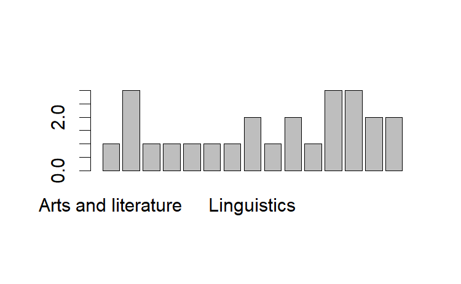

```r
with(dat, plot(Academic_background))
```

R does not depict all levels because there are so many. A solution is a horizontal bar chart but then we have ensure that the figure margin is wide enough so the levels are readable. We can change the figure margins with the function `par()`:

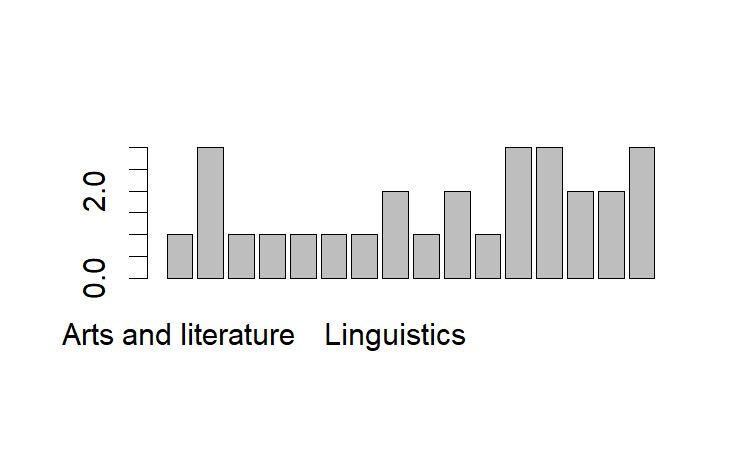

```r
barplot(tab)    # also plots missing values
```

```r
?par
```

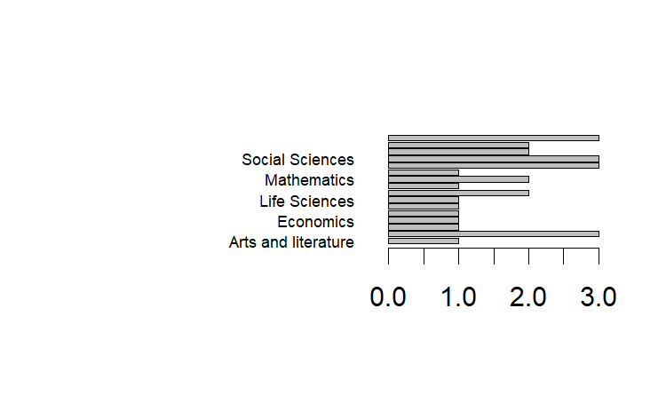

```r
par(mar = c(5, 12, 4, 2) + 0.1)
barplot(tab, horiz = TRUE, las = 1, cex.names = 0.6)
```

In **ggplot2** we can create a horizontal bar chart by specifying the factor (`Academic_background`) to `y` aesthetic (instead of `x`):

```r
par(mar = c(5, 4, 4, 2) + 0.1)    # Change graphical parameters back to default
```

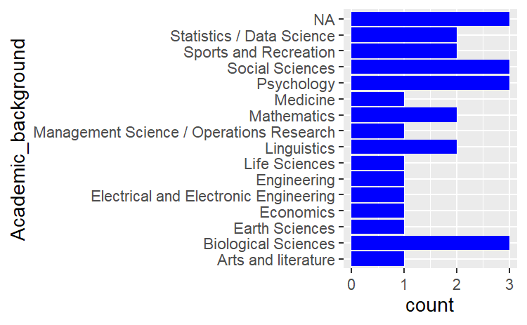

```r
ggplot(data = dat, mapping = aes(y = Academic_background)) +
  geom_bar(fill = "blue")
```

```r
with(dat, `R course`)
```

```
 [1] ""    ""    ""    "yes" "no"  "yes" "yes" "no"  "no"  "yes"
[11] "no"  "yes" "no"  "no"  "yes" "no"  "no"  "no"  "no"  "yes"
[21] "yes" "no"  "no"  "yes" "no"  "no"  "no"  "yes"
```

```r
dat <- within(dat, R_course <- factor(na_if(`R course`, "")))
with(dat, str(R_course))
```

```
 Factor w/ 2 levels "no","yes": NA NA NA 2 1 2 2 1 1 2 ...
```

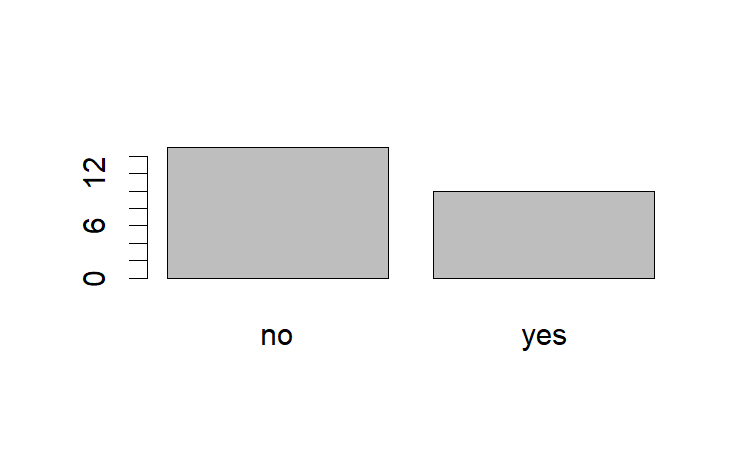

```r
with(dat, plot(R_course))
```

```r
with(dat, `R skills`)
```

```
 [1] ""             ""             ""             "Low"
 [5] "Intermediate" "Intermediate" "Low"          "Low"
 [9] "Intermediate" "Intermediate" "Low"          "Low"
[13] "Intermediate" "Intermediate" "Intermediate" "Low"
[17] "Low"          "Intermediate" "Low"          "Intermediate"
[21] "Low"          "Intermediate" "Low"          "Low"
[25] "Low"          "Low"          "Low"          "None"
```

We can convert `R.skills` into an ordinal variable by using the argument `ordered` in `factor()`:

```r
dat <- within(dat, R_skills <- na_if(`R skills`, ""))
with(dat, str(R_skills))
```

```
 chr [1:28] NA NA NA "Low" "Intermediate" "Intermediate" ...
```

```r
dat <- within(dat, R_skills <- factor(R_skills, ordered = TRUE,
                       levels = c("None", "Low", "Intermediate", "Advanced")))
with(dat, str(R_skills))
```

```
 Ord.factor w/ 4 levels "None"<"Low"<"Intermediate"<..: NA NA NA 2 3 3 2 2 3 3 ...
```

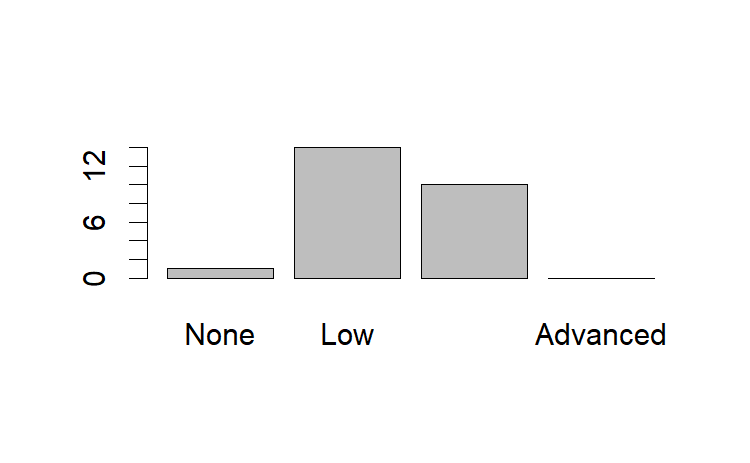

```r
with(dat, plot(R_skills))
```

```r
with(dat, `Means of transportation`)
```

```
 [1] ""
 [2] ""
 [3] ""
 [4] "public transportation (bus and/or train)"
 [5] "bike"
 [6] "public transportation (bus and/or train)"
 [7] "car / motorbike"
 [8] "bike"
 [9] "car / motorbike"
[10] "public transportation (bus and/or train)"
[11] "public transportation (bus and/or train)"
[12] "bike"
[13] "bike"
[14] "public transportation (bus and/or train)"
[15] "bike"
[16] "bike"
[17] "bike"
[18] "bike"
[19] "public transportation (bus and/or train)"
[20] "bike"
[21] "public transportation (bus and/or train)"
[22] "public transportation (bus and/or train)"
[23] "public transportation (bus and/or train)"
[24] "bike"
[25] "bike"
[26] "bike"
[27] "bike"
[28] "public transportation (bus and/or train)"
```

Change labels to make them shorter (but again specify them in the same order as the current order, because otherwise you also need to use the argument `levels`):

```r
dat <- within(dat,
              Means_of_transportation <- na_if(`Means of transportation`, ""))
```

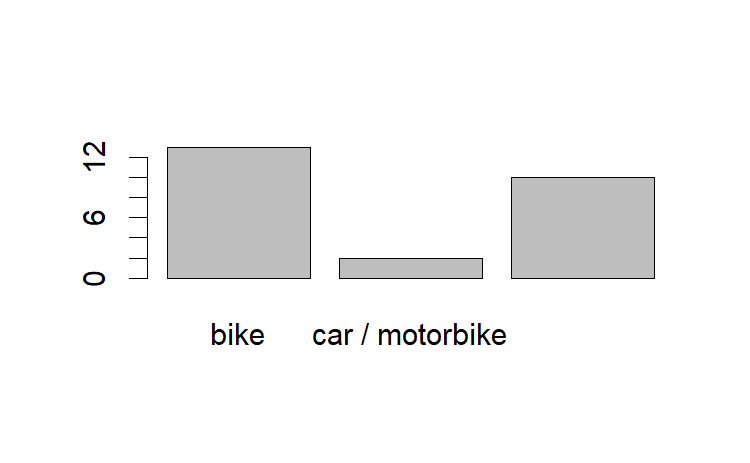

```r
dat <- within(dat,
              Means_of_transportation <- factor(Means_of_transportation,
                                                labels = c("bike",
                                                           "car / motorbike",
                                                           "public transport")))
with(dat, plot(Means_of_transportation))
```

```r
with(dat, `Distance to class`)
```

```
 [1] 10000.0      NA      NA    92.0     6.0     3.0    75.0
 [8]    25.0     3.0     6.0     4.0     6.0    39.0    10.0
[15]     2.0     3.0     1.0    60.0   101.8     2.0    10.0
[22]    50.0     3.0     2.5     2.0     5.0    15.0     0.0
```

How many missing values?

```r
with(dat, str(`Distance to class`))
```

```
 num [1:28] 10000 NA NA 92 6 3 75 25 3 6 ...
```

In tidyverse, the function `arrange()` (of the subpackage **dplyr**) can be used to order a data frame on the basis of the values in particular columns. The default is ascending order (i.e. from the smallest to the largest value) but the function `desc()` can be used to sort in descending order (i.e. from the largest to the smallest value):

```r
with(dat, sum(is.na(`Distance to class`)))
```

```
[1] 2
```

```r
dat %>% arrange(`Distance to class`)
```

| Timestamp | Gender | Nationality | Date of Birth | Academic background | R course | R skills | Distance to class | Time to get here | Means of transportation | Where did you here about the MaStat program? | Music preference | Belgian | Academic_background | R_course | R_skills | Means_of_transportation |
| --- | --- | --- | --- | --- | --- | --- | --- | --- | --- | --- | --- | --- | --- | --- | --- | --- |
| 25/09/2025 10:13:13 |  |  | 25/09/2025 | Arts and literature | yes | None | 0.0 | 0 | public transportation (bus and/or train) | Friend/Colleague | Classical | Other | Arts and literature | yes | None | public transport |
| 25/09/2025 10:09:27 | male | Belgium | 29/01/2002 | Sports and Recreation | no | Low | 1.0 | 5 | bike | Friend/Colleague | Rap/slow jam | BEL | Sports and Recreation | no | Low | bike |
| 25/09/2025 10:09:07 | male | Ukraine | 19/02/1987 | Social Sciences | yes | Intermediate | 2.0 | 10 | bike | UGent Website | Classical | Other | Social Sciences | yes | Intermediate | bike |
| 25/09/2025 10:09:07 | male | Ukraine | 19/02/1987 | Social Sciences | yes | Intermediate | 2.0 | 10 | bike | UGent Website | Classical | Other | Social Sciences | yes | Intermediate | bike |
| 25/09/2025 10:12:14 | female | Belgium | 15/05/1999 | Management Science / Operations Research | no | Low | 2.0 | 7 | bike | Friend/Colleague | Classical | BEL | Management Science / Operations Research | no | Low | bike |
| 25/09/2025 10:11:55 | female | Belgium | 19/11/1990 | Biological Sciences | yes | Low | 2.5 | 15 | bike | UGent Website | Classical | BEL | Biological Sciences | yes | Low | bike |
| 25/09/2025 10:06:49 | male | Colombia | 10/12/1992 | Social Sciences | yes | Intermediate | 3.0 | 30 | public transportation (bus and/or train) | Other | Classical | Other | Social Sciences | yes | Intermediate | public transport |
| 25/09/2025 10:07:56 | female | Belgium | 16/07/1986 | Statistics / Data Science | no | Intermediate | 3.0 | 9 | car / motorbike | UGent Website | House/Techno | BEL | Statistics / Data Science | no | Intermediate | car / motorbike |
| 25/09/2025 10:09:25 | male | Belgium | 27/12/2003 | Linguistics | no | Low | 3.0 | 7 | bike | Other | Classical | BEL | Linguistics | no | Low | bike |
| 25/09/2025 10:11:29 | female | India | 30/05/1988 | Electrical and Electronic Engineering | no | Low | 3.0 | 25 | public transportation (bus and/or train) | UGent Website | Rap/slow jam | Other | Electrical and Electronic Engineering | no | Low | public transport |

[output cut: 18 more lines]

```r
dat %>% arrange(desc(`Distance to class`))
```

| Timestamp | Gender | Nationality | Date of Birth | Academic background | R course | R skills | Distance to class | Time to get here | Means of transportation | Where did you here about the MaStat program? | Music preference | Belgian | Academic_background | R_course | R_skills | Means_of_transportation |
| --- | --- | --- | --- | --- | --- | --- | --- | --- | --- | --- | --- | --- | --- | --- | --- | --- |
| 08/02/2025 16:28:41 |  |  |  |  |  |  | 10000.0 | NA |  |  |  | Other | NA | NA | NA | NA |
| 25/09/2025 10:09:30 | male | Belgium | 14/02/1992 | Statistics / Data Science | no | Low | 101.8 | 0 | public transportation (bus and/or train) | Friend/Colleague | Rap/slow jam | BEL | Statistics / Data Science | no | Low | public transport |
| 25/09/2025 10:02:44 | female | China | 16/01/1993 | Mathematics | yes | Low | 92.0 | 99 | public transportation (bus and/or train) | UGent Website | House/Techno | Other | Mathematics | yes | Low | public transport |
| 25/09/2025 10:06:57 | male | Belgium | 21/03/1991 | Biological Sciences | yes | Low | 75.0 | 80 | car / motorbike | UGent Website | House/Techno | BEL | Biological Sciences | yes | Low | car / motorbike |
| 25/09/2025 10:09:25 | male | France | 06/10/1996 | Psychology | no | Intermediate | 60.0 | 90 | bike | UGent Website | Rap/slow jam | Other | Psychology | no | Intermediate | bike |
| 25/09/2025 10:11:02 | male | Turkey | 08/05/1998 | Biological Sciences | no | Intermediate | 50.0 | 95 | public transportation (bus and/or train) | UGent Website | Rap/slow jam | Other | Biological Sciences | no | Intermediate | public transport |
| 25/09/2025 10:08:41 | male | Belgium | 02/04/2000 | Life Sciences | no | Intermediate | 39.0 | 16 | bike | Other | House/Techno | BEL | Life Sciences | no | Intermediate | bike |
| 25/09/2025 10:09:25 | male | Israel | 05/08/1998 | Psychology | no | Low | 25.0 | 25 | bike | UGent Website | House/Techno | Other | Psychology | no | Low | bike |
| 25/09/2025 10:12:51 | female | Belgium | 04/04/1999 | Sports and Recreation | no | Low | 15.0 | 30 | bike | UGent Website | Classical | BEL | Sports and Recreation | no | Low | bike |
| 25/09/2025 10:08:51 | male | Belgium | 03/03/1979 | Linguistics | no | Intermediate | 10.0 | 15 | public transportation (bus and/or train) | FLAMES website | House/Techno | BEL | Linguistics | no | Intermediate | public transport |

[output cut: 18 more lines]

R of course has many functions for computing **numerical summaries** (i.e. descriptive statistics). By default, however, they return `NA` if there are any `NA`’s in your data. If you want to have the numerical summary for the non-missing data, then each of these functions has to be used with the argument `na.rm = TRUE`:

```r
dat %>% arrange(desc(`Time to get here`))
```

| Timestamp | Gender | Nationality | Date of Birth | Academic background | R course | R skills | Distance to class | Time to get here | Means of transportation | Where did you here about the MaStat program? | Music preference | Belgian | Academic_background | R_course | R_skills | Means_of_transportation |
| --- | --- | --- | --- | --- | --- | --- | --- | --- | --- | --- | --- | --- | --- | --- | --- | --- |
| 25/09/2025 10:02:44 | female | China | 16/01/1993 | Mathematics | yes | Low | 92.0 | 99 | public transportation (bus and/or train) | UGent Website | House/Techno | Other | Mathematics | yes | Low | public transport |
| 25/09/2025 10:11:02 | male | Turkey | 08/05/1998 | Biological Sciences | no | Intermediate | 50.0 | 95 | public transportation (bus and/or train) | UGent Website | Rap/slow jam | Other | Biological Sciences | no | Intermediate | public transport |
| 25/09/2025 10:09:25 | male | France | 06/10/1996 | Psychology | no | Intermediate | 60.0 | 90 | bike | UGent Website | Rap/slow jam | Other | Psychology | no | Intermediate | bike |
| 25/09/2025 10:06:57 | male | Belgium | 21/03/1991 | Biological Sciences | yes | Low | 75.0 | 80 | car / motorbike | UGent Website | House/Techno | BEL | Biological Sciences | yes | Low | car / motorbike |
| 25/09/2025 13:40:27 | male | India | 19/10/1990 | Mathematics | yes | Low | 10.0 | 50 | public transportation (bus and/or train) | UGent Website | Classical | Other | Mathematics | yes | Low | public transport |
| 25/09/2025 10:08:05 | female | China | 29/08/2000 | Medicine | yes | Intermediate | 6.0 | 40 | public transportation (bus and/or train) | UGent Website | I don't like music | Other | Medicine | yes | Intermediate | public transport |
| 25/09/2025 10:06:49 | male | Colombia | 10/12/1992 | Social Sciences | yes | Intermediate | 3.0 | 30 | public transportation (bus and/or train) | Other | Classical | Other | Social Sciences | yes | Intermediate | public transport |
| 25/09/2025 10:08:30 | female | Turkey | 30/04/1998 | Engineering | no | Low | 4.0 | 30 | public transportation (bus and/or train) | Other | House/Techno | Other | Engineering | no | Low | public transport |
| 25/09/2025 10:12:27 | female | Vietnam | 25/09/2025 | Economics | no | Low | 5.0 | 30 | bike | UGent Website | Classical | Other | Economics | no | Low | bike |
| 25/09/2025 10:12:51 | female | Belgium | 04/04/1999 | Sports and Recreation | no | Low | 15.0 | 30 | bike | UGent Website | Classical | BEL | Sports and Recreation | no | Low | bike |

[output cut: 18 more lines]

```r
with(dat, min(`Distance to class`))
```

```
[1] NA
```

```r
with(dat, min(`Distance to class`, na.rm = TRUE))
```

```
[1] 0
```

```r
with(dat, max(`Distance to class`, na.rm = TRUE))
```

```
[1] 10000
```

Various summary statistics can be combined in a vector:

```r
with(dat, range(`Distance to class`, na.rm = TRUE))
```

```
[1]     0 10000
```

The tidyverse counterpart of this is to work with the `summarise()` function (of the **dplyr** subpackage):

```r
with(dat,
     c(mean = mean(`Distance to class`, na.rm = TRUE),
       var = var(`Distance to class`, na.rm = TRUE),
       sd = sd(`Distance to class`, na.rm = TRUE))
     )
```

```
        mean          var           sd
    404.8577 3830866.9585    1957.2601
```

Some robust summaries:

```r
dat %>% summarise(
  mean = mean(`Distance to class`, na.rm = TRUE),
  var = var(`Distance to class`, na.rm = TRUE),
  sd = sd(`Distance to class`, na.rm = TRUE))
```

```
# A tibble: 1 × 3
   mean      var    sd
  <dbl>    <dbl> <dbl>
1  405. 3830867. 1957.
```

```r
with(dat, median(`Distance to class`, na.rm = TRUE))
```

```
[1] 6
```

```r
with(dat, quantile(`Distance to class`, na.rm = TRUE))
```

```
     0%     25%     50%     75%    100%
    0.0     3.0     6.0    35.5 10000.0
```

```r
with(dat, quantile(`Distance to class`, probs = (1:10) / 10, na.rm = TRUE))
```

```
    10%     20%     30%     40%     50%     60%     70%     80%
    2.0     2.5     3.0     4.0     6.0    10.0    20.0    50.0
    90%    100%
   83.5 10000.0
```

```r
with(dat, summary(`Distance to class`, na.rm = TRUE))
```

```
   Min. 1st Qu.  Median    Mean 3rd Qu.    Max.    NA's
    0.0     3.0     6.0   404.9    35.5 10000.0       2
```

Check:

```r
with(dat, fivenum(`Distance to class`, na.rm = TRUE))
```

```
[1]     0     3     6    39 10000
```

```r
with(dat, IQR(`Distance to class`, na.rm = TRUE))
```

```
[1] 32.5
```

**Graphical summaries** are provided by the histogram, boxplot or QQ-plot.

**Histogram**:

```r
with(dat, hist(`Distance to class`))
```

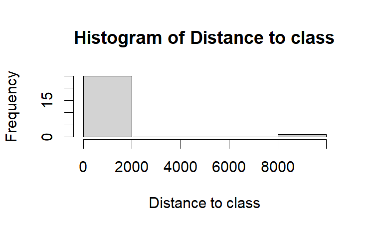

```r
with(dat, hist(`Distance to class`))
```

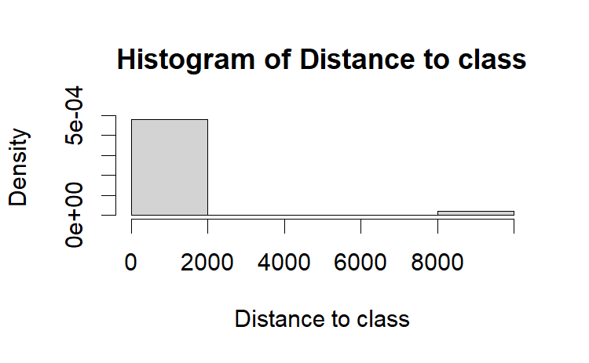

```r
with(dat, hist(`Distance to class`, freq = FALSE))
```

Identify the outliers (e.g. `` `Distance to class` `` == 10000):

```r
?hist
```

```r
?which
```

```r
with(dat, which(`Distance to class` > 7000))
```

```
[1] 1
```

```r
with(dat, `Distance to class`[1])
```

```
[1] 10000
```

```r
with(dat, match(10000, `Distance to class`))
```

```
[1] 1
```

We can subset the data by excluding an observation (e.g. obs 1):

```r
with(dat, which(`Distance to class` == 10000))
```

```
[1] 1
```

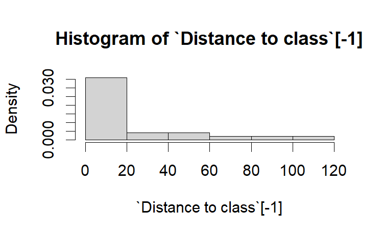

```r
with(dat, hist(`Distance to class`[-1], freq = FALSE))
```

The tidyverse counterpart to excluding observations is to use the function `filter()` (from the subpackage **dplyr**). Since we cannot include base R functions (like `hist()`) in pipe chains (using `%>%`), we have to create a new data set:

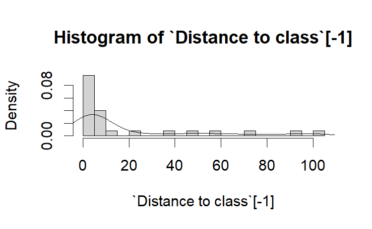

```r
with(dat, {
  hist(`Distance to class`[-1], freq = FALSE, breaks = 20)
  lines(density(`Distance to class`[-1], na.rm = TRUE))
        })
```

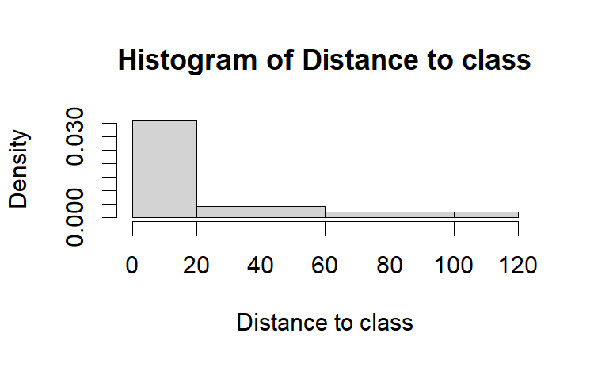

```r
sub <- dat %>% filter(`Distance to class` < 10000)
with(sub, hist(`Distance to class`, freq = FALSE))
```

Further on, if we use the variable `` `Distance to class` `` then we will remove the outlier(s) from the data. You could use the new data set `sub` but then you lose all the other information about this (first) observation. This is not always what we want because outliers may have valid information on all of the other variables.

**Boxplot**:

```r
with(dat, boxplot(`Distance to class`, ylab = "Distance to class",
                  main = "boxplot of Distance"))
```

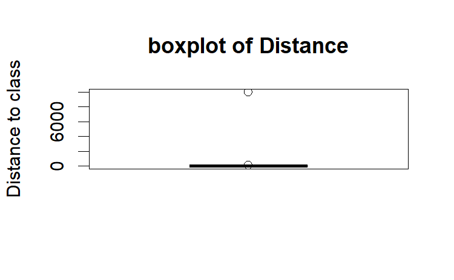

```r
with(dat, boxplot(`Distance to class`, ylab = "Distance to class",
                  main = "boxplot of Distance"))
```

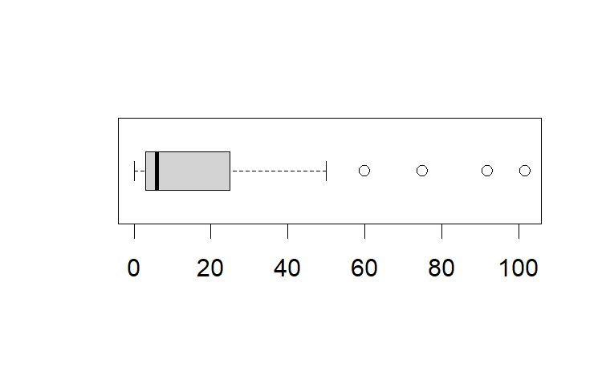

```r
with(sub, boxplot(`Distance to class`, horizontal = TRUE))
```

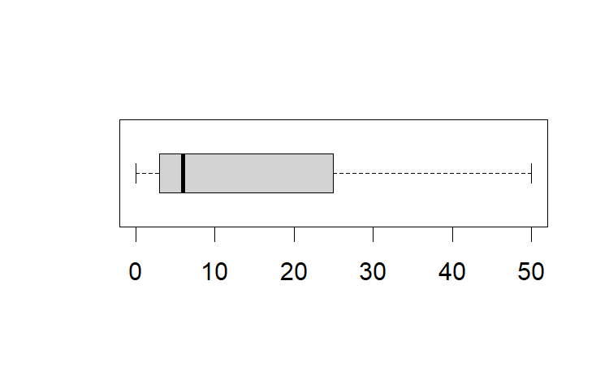

```r
with(sub, boxplot(`Distance to class`, horizontal = TRUE, outline = FALSE))
```

The function `Boxplot()` from the package **car** is more informative than the base R function in that it plots the row ID’s of the outliers:

```r
?boxplot
```

```
[1]  1 19
```

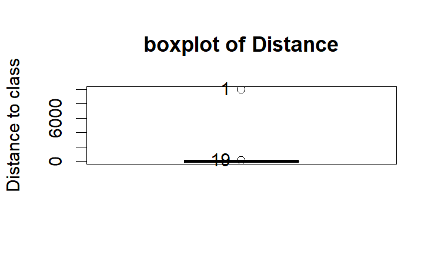

```r
with(dat, Boxplot(`Distance to class`, ylab = "Distance to class",
                  main = "boxplot of Distance"))
```

**QQ-plot**: = Check for normality (relevant for various statistical tests, e.g. t-test)

With outliers:

```r
with(dat, {
  qqnorm(`Distance to class`)
  qqline(`Distance to class`)
})
```

Without outliers:

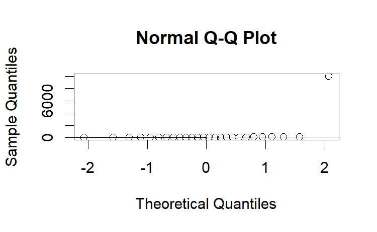

```r
with(dat, {
  qqnorm(`Distance to class`)
  qqline(`Distance to class`)
})
```

A histogram and boxplot side by side:

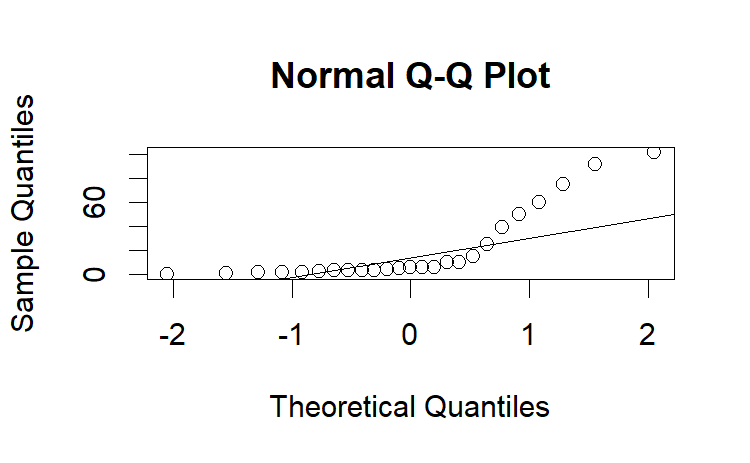

```r
with(sub, {
  qqnorm(`Distance to class`)
  qqline(`Distance to class`)
})
```

```r
?par
```

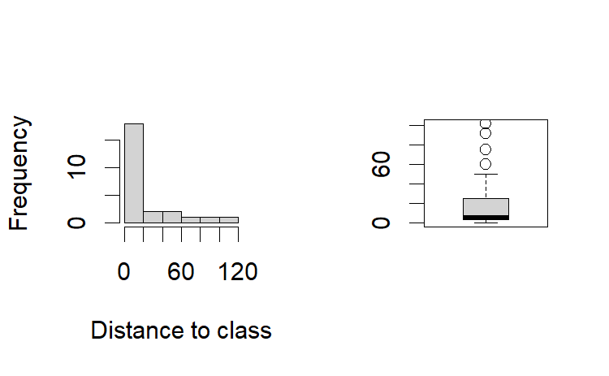

```r
par(mfrow = c(1, 2))    # split the screen into 1 row and 2 columns
with(sub, {
  hist(`Distance to class`, xlab = "Distance to class", main = "")
  boxplot(`Distance to class`)
})
```

Add the QQ-plot:

```r
par(mfrow = c(1, 1))    # put back to default
```

```r
?layout
```

In tidyverse, histograms, boxplots and qq-plots can be made by choosing the appropriate “geom layers” with **ggplot2**. Note that the QQ-plot requires the numeric variable to be specified to the aesthetic `sample`:

[figure not shown]

```r
layout(matrix(c(1, 1, 2, 3), nrow = 2, ncol = 2, byrow = TRUE))
with(sub, {
  qqnorm(`Distance to class`)
  qqline(`Distance to class`)
  hist(`Distance to class`, xlab = "Distance to class", main = "")
  boxplot(`Distance to class`)
})
```